# 308.6. SSO Lightcurves

For the Rubin Science Platform at data.lsst.cloud.  
Data Release: [Data Preview 1](https://dp1.lsst.io/)  
Container Size: large  
LSST Science Pipelines version: r29.2.0  
Last verified to run: 2026-07-01  
Repository: github.com/lsst/tutorial-notebooks

**Learning objective:** How to retrieve Solar System Object photometry for lightcurve analysis in Data Preview 1.

**LSST data products:** `SSObject`, `MPCORB`, `DiaSource`, `SSSource`

**Packages:** `matplotlib`, `numpy`, `astropy.units`, `lsst.rsp`, `lsst.utils.plotting`

**Credit:** Originally developed by the Rubin Community Science team. Please consider acknowledging them if this notebook is used for the preparation of journal articles, software releases, or other notebooks.

**Get Support:** Everyone is encouraged to ask questions or raise issues in the [Support Category](https://community.lsst.org/c/support) of the Rubin Community Forum. Rubin staff will respond to all questions posted there.

## 1. Introduction

The observed brightness of a Solar System Object (SSO) changes primarily due to the following factors:

- Heliocentric and observer (topocentric) distances
- Viewing geometry, i.e. the Sun-SSO-observer phase angle
- Rotational variation, most often shape-driven

For active SSOs (comets and active asteroids), the observed photometry is also affected by the photometric properties of the emitted dust and gas and is more complicated to model.

This notebook demonstrates how to retrieve SSO photometry from Data Preview 1 (DP1) and how to analysis the lightcurve, accounting for viewing distances and geometry.

> **Warning:** DP1 presents only a fraction of the data that will be released with the full LSST. As such the lightcurve and phase angle coverage of SSOs in DP1 is limited* and this science analysis notebook is for demonstration purposes.

As part of [Rubin First Look](https://rubinobservatory.org/gallery/image-releases/rubin-first-look) (RFL) and Solar System Processing (SSP) testing there has been a significant amount of LSSTCam SSO photometry submitted to the Minor Planet Center (MPC). Furthermore the pre-LSST alert stream contains suitable coverage of a number of SSOs. These data are more suitable for full lightcurve analysis, as demonstrated by recent publications by [Greenstreet et al. 2026](https://doi.org/10.3847/2041-8213/ae2a30) and [Kurlander et al. 2026](https://doi.org/10.3847/2515-5172/ae67fe), but require different methods to access and analyse compared to the upcoming LSST prompt products and data releases. See [Prompt Products documentation](https://prompt-products.lsst.io/) for information on alerts and an MPC photometry tutorial.

**Related tutorials:** The 100-level tutorials demonstrate how to use the TAP service. The 200-level tutorials introduce the types of catalog data; see 201.5, 201.7, 201.8 and 201.9 for information on the `DiaSource`, `SSObject`, `SSSource` and `MPCORB` tables respectively. The 300-level tutorials demonstrate science analysis; see 308.4 for details on SSO photometry.

### 1.1. Import packages

Import `numpy`, a fundamental package for scientific computing with arrays in Python (numpy.org), and `matplotlib`, a comprehensive library for data visualization ([matplotlib.org](https://matplotlib.org/); [matplotlib gallery](https://matplotlib.org/stable/gallery/index.html)). Import `astropy.units` to convert between fluxes and magnitudes.

From the `lsst` package, import modules for accessing the Table Access Protocol (TAP) service from the LSST Science Pipelines (pipelines.lsst.io).

```python
import numpy as np
import matplotlib.pyplot as plt

import astropy.units as u

from lsst.rsp import get_tap_service
from lsst.utils.plotting import (get_multiband_plot_colors,
                                 get_multiband_plot_symbols,
                                 get_multiband_plot_linestyles)
```

### 1.2. Define parameters and functions

Define colors, symbols, and linestyles to represent the six LSST filters, $ugrizy$.

```python
filter_names = ['u', 'g', 'r', 'i', 'z', 'y']
filter_colors_white = get_multiband_plot_colors()
filter_colors_black = get_multiband_plot_colors(dark_background=True)
filter_symbols = get_multiband_plot_symbols()
filter_linestyles = get_multiband_plot_linestyles()
```

Get an instance of the TAP service, and assert that it exists.

```python
service = get_tap_service("tap")
assert service is not None
```

The DP1 `MPCORB` table provides the orbital elements for each `ssObjectId` from the Minor Planet Center database. The perihelion `q` and eccentricity `e` are provided but semi-major axis must be calculated.

Define a function to calculate the semi-major axis of an asteroid's orbit.

```python
def calc_semimajor_axis(q, e):
    """
    Given a perihelion distance and orbital eccentricity,
      calculate the semi-major axis of the orbit.

    Parameters
    ----------
    q: float
        Distance at perihelion, in au.
    e: float
        Orbital eccentricity.

    Returns
    -------
    a: float
        Semi-major axis of the orbit, in au.
        q = a(1-e), so a = q/(1-e)
    """

    return q / (1.0 - e)
```

## 2. Define target

The data specific to SSOs in DP1 are spread across four tables (see [DP1 schema](https://sdm-schemas.lsst.io/dp1.html)). Object level information is contained in `SSObject` and `MPCORB` tables, where each row corresponds to a unique SSO and is indexed by `ssObjectId`. Source level information is contained in `DiaSource` and `SSSource`, where each row is a unique observation of an SSO indexed by `diaSourceId` and associated with an `ssObjectId` to identify the object. As such querying data for SSOs will often involve joining tables on `ssObjectId` and/or `diaSourceId`.

> **Warning:** DP1 does not contain all the fields as listed in the [Data Products Definition Document](https://lse-163.lsst.io/). This is especially true for the `SSObject` table.

> **Warning:** Future data releases will treat the association of `diaSourceId` and `ssObjectID` differently to DP1 - a given `ssObjectId` will be assigned to the `diaSourceId` nearest the predicted SSO position at the time of exposure (this is encapsulated by `SSSource:diaDistanceRank`; see [Source Assocation](https://prompt-products.lsst.io/processing/association/index.html) prompt products documentation for details).

> **Warning:** For static transients the `ForcedSourceOnDiaObject` table is recommended for retrieving photometry (see tutorial 205.1). As SSO DiaSources are not static it is recommended to use the `DiaSource` table directly.

### 2.1. Select an `ssObjectId`

Select an SSO with a large number of observations to look at its lightcurve. The following query retrieves ssObjectId, sorted by the total number of observations: `numObs`. Order the results by `numObs` in descending order.

```python
query = "SELECT ssObjectId, numObs "\
        "FROM dp1.SSObject as sso "\
        "ORDER BY numObs DESC"
```

Submit the query as a job to the TAP service. Run the job and wait until the job phase is either "COMPLETED" or "ERROR", then print the job phase and the error message, if applicable.

```python
job = service.submit_job(query)
print('Job URL is', job.url)
job.run()
job.wait(phases=['COMPLETED', 'ERROR'])
print('Job phase is', job.phase)
if job.phase == 'ERROR':
    job.raise_if_error()
```

```
Job URL is https://data.lsst.cloud/api/tap/async/x40a7alwncuv4bum
Job phase is COMPLETED
```

```python
assert job.phase == 'COMPLETED'
results = job.fetch_result().to_table()
```

Print the first 10 results showing the number of observations in descending order.

```python
results[:10]
```

*Table length=10*

| ssObjectId int64 | numObs int32 |
| --- | --- |
| 21163620217073748 | 133 |
| 23133931615301680 | 82 |
| 21163637482928473 | 80 |
| 21164728252512342 | 66 |
| 23133931615301681 | 65 |
| 23133931615301682 | 63 |
| 21164741002015298 | 39 |
| 21163645768577093 | 33 |
| 23133931615301687 | 32 |
| 23133931615301942 | 30 |

Save space in memory by deleting the job and the retrieved results.

```python
job.delete()
del results
```

### 2.2. Retrieve orbit information

Select the DP1 SSO with the most observations for lightcurve analysis (`ssObjectId` = 21163620217073748). Get information such as name and orbital parameters for the selected `ssObjectId`. This requires a `JOIN` between the `MPCORB` and `SSObject` tables.

```python
ssoid = 21163620217073748
```

```python
query = "SELECT mpc.mpcDesignation, "\
        "mpc.q, mpc.e, mpc.incl, "\
        "sso.numObs "\
        "FROM dp1.MPCORB as mpc "\
        "INNER JOIN dp1.SSObject as sso "\
        "ON mpc.ssObjectId = sso.ssObjectId "\
        "WHERE mpc.ssObjectId = 21163620217073748"
```

```python
job = service.submit_job(query)
print('Job URL is', job.url)
job.run()
job.wait(phases=['COMPLETED', 'ERROR'])
print('Job phase is', job.phase)
if job.phase == 'ERROR':
    job.raise_if_error()
```

```
Job URL is https://data.lsst.cloud/api/tap/async/tq4u9tzpz59sgl7j
Job phase is COMPLETED
```

```python
assert job.phase == 'COMPLETED'
results = job.fetch_result().to_table()
```

Calculate the orbital semi-major axis `a` and look at the object's orbital parameters:

```python
results['a'] = calc_semimajor_axis(results['q'], results['e'])
results
```

*Table length=1*

| mpcDesignation str13 | q AU float64 | e float64 | incl deg float64 | numObs int32 | a float64 |
| --- | --- | --- | --- | --- | --- |
| 2003 QT30 | 1.70936064352526 | 0.09492430251121 | 26.6295069323684 | 133 | 1.88863831861581 |

```python
mpcDes = results['mpcDesignation'][0]
mpcDes
```

```
np.str_('2003 QT30')
```

Clean up.

```python
job.delete()
del results
```

### 2.3. Retrieve observation data

To get all information for observations of the SSO, the query must `JOIN` the tables `DiaSource` and `SSSource`.

Flag columns are used to identify observations that the photometry algorithms may have had issues with, these are also retrieved. See tutorial 308.4 Photometry for more details.

```python
diaFlags = np.array(['isDipole', 'dipoleFitAttempted', 'pixelFlags',
                     'pixelFlags_offimage', 'pixelFlags_edge',
                     'pixelFlags_interpolated', 'pixelFlags_saturated', 'pixelFlags_cr',
                     'pixelFlags_bad', 'pixelFlags_suspect',
                     'pixelFlags_interpolatedCenter', 'pixelFlags_saturatedCenter',
                     'pixelFlags_crCenter', 'pixelFlags_suspectCenter', 'centroid_flag',
                     'apFlux_flag', 'apFlux_flag_apertureTruncated', 'psfFlux_flag',
                     'psfFlux_flag_noGoodPixels', 'psfFlux_flag_edge',
                     'forced_PsfFlux_flag', 'forced_PsfFlux_flag_noGoodPixels',
                     'forced_PsfFlux_flag_edge', 'shape_flag', 'shape_flag_no_pixels',
                     'shape_flag_not_contained', 'shape_flag_parent_source',
                     'trail_flag_edge', 'pixelFlags_streak', 'pixelFlags_streakCenter',
                     'pixelFlags_injected', 'pixelFlags_injectedCenter',
                     'pixelFlags_injected_template',
                     'pixelFlags_injected_templateCenter', 'pixelFlags_nodata',
                     'pixelFlags_nodataCenter'])
```

```python
query = """SELECT dia.diaSourceId, dia.midpointMjdTai, dia.band,
           dia.psfFlux, dia.psfFluxErr, dia.scienceFlux, dia.scienceFluxErr,
           sss.topocentricDist, sss.heliocentricDist, sss.phaseAngle, {}
           FROM dp1.DiaSource as dia
           INNER JOIN dp1.SSSource as sss
           ON dia.diaSourceId = sss.diaSourceId
           WHERE dia.ssObjectId = {}
        """.format(','.join(['dia.'+x for x in diaFlags]), ssoid)
print(query)
```

[output not shown]

```python
job = service.submit_job(query)
job.run()
job.wait(phases=['COMPLETED', 'ERROR'])
print('Job phase is', job.phase)
if job.phase == 'ERROR':
    job.raise_if_error()
```

```
Job phase is COMPLETED
```

```python
assert job.phase == 'COMPLETED'
results = job.fetch_result()
```

Store the results in a pandas dataframe as `df_obs`.

```python
df_obs = results.to_table().to_pandas()
```

Option to print results.

```python
# df_obs
```

Clean up.

```python
job.delete()
del results
```

### 2.4. Calculate Magnitudes

Rubin reports fluxes, this is especially important for forced photometry and non-detections of static transients. However it is common to analyze SSO lightcurves with magnitude, therefore we use `astropy.units` to convert flux `nJy` to `ABmag`.

> **Warning** DiaSource detections can have negative flux, in these cases the `RuntimeWarning: invalid value encountered in log10` will be raised.

It is also possible to perform the flux to magnitude conversion in the ADQL query using `scisql_nanojanskyToAbMag` (see tutorial 103.3) but this function is not recommended when negative fluxes are present.

```python
df_obs['psfABmag'] = (np.array(df_obs['psfFlux']) * u.nJy).to(u.ABmag).value
df_obs['scienceABmag'] = (np.array(df_obs['scienceFlux']) * u.nJy).to(u.ABmag).value

df_obs['psfABmagErr'] = ((2.5 / np.log(10)) * (df_obs['psfFluxErr'] / df_obs['psfFlux']))
df_obs['scienceABmagErr'] = ((2.5 / np.log(10)) * (df_obs['scienceFluxErr'] / df_obs['scienceFlux']))
```

### 2.5. Reduced Magnitude

The reduced magnitude of an SSO accounts for viewing distances at the time of observation, where apparent magnitude is corrected to a heliocentric and topocentric distance of 1 au. By removing the effects of observing distance, the reduced magnitude lightcurve is determined by phase angle effects and rotational brightness variations.

```python
thdist = df_obs['topocentricDist']*df_obs['heliocentricDist']
df_obs['red_psfABmag'] = df_obs['psfABmag'] - 5.0*np.log10(thdist)
df_obs['red_scienceABmag'] = df_obs['scienceABmag'] - 5.0*np.log10(thdist)
```

## 3. SSO Lightcurve Analysis

Select the type of magnitude measurement to use for the SSO lightcurve. For DP1 one should generally use the PSF measurements of flux.

In this example `psfAbmag` which was measured on the difference image gives a more accurate observation on the first night compared to `scienceABmag`, due to background contamination of an extended source in the science image. Take a closer look at the cutouts for `diaSourceId` = 600438911280349188 and 600438911951437875 by using tutorial 308.5 Image stamps.

```python
mag_col = 'psfABmag'
```

Use the `DiaSource` flag columns to identify observations that should probably be excluded from scientific analysis.

```python
any_flag_mask = df_obs[diaFlags].any(axis=1)
df_obs[any_flag_mask][['diaSourceId'] + list(diaFlags[df_obs[diaFlags].any()])]
```

|  | diaSourceId | isDipole | dipoleFitAttempted | centroid_flag | apFlux_flag | psfFlux_flag | forced_PsfFlux_flag | shape_flag |
| --- | --- | --- | --- | --- | --- | --- | --- | --- |
| 8 | 600447733812690946 | True | True | False | False | False | False | False |
| 13 | 600447736631263242 | True | True | False | False | False | False | False |
| 39 | 600447734351134753 | True | True | False | False | False | False | False |
| 77 | 600452146489458689 | False | False | True | True | True | True | True |

Plot the magnitude brightness of the SSO as a function of time denoting observations in different filters. Indicate observations with at least one DiaSource flag; these observations should generally be excluded from further analysis.

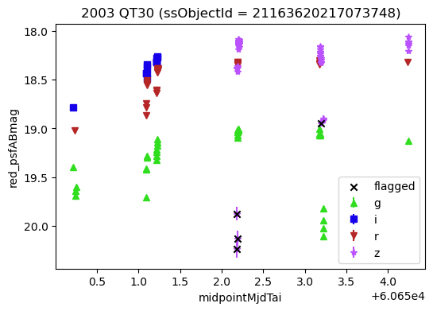

```python
x_plot = 'midpointMjdTai'
y_plot = 'red_{}'.format(mag_col)
yErr_plot = '{}Err'.format(mag_col)

df_plot = df_obs
df_plot2 = df_obs[any_flag_mask]

fig, ax = plt.subplots(figsize=(6, 4))

for i, filt in enumerate(np.unique(df_plot['band'])):
    _df_plot = df_plot[df_plot['band'] == filt]
    ax.errorbar(_df_plot[x_plot], _df_plot[y_plot], _df_plot[yErr_plot],
                c=filter_colors_white[filt],
                fmt=filter_symbols[filt],
                label=filt)

ax.scatter(df_plot2[x_plot], df_plot2[y_plot],
           c='k', marker='x',
           zorder=5, label='flagged')

ax.legend()
ax.set_xlabel(x_plot)
ax.set_ylabel(y_plot)
ax.invert_yaxis()

plt.title(f"{mpcDes} (ssObjectId = {ssoid})")

plt.show()
```

> **Figure 1:** Magnitude brightness of an SSO as a function of time. Marker colour and symbol denote observations in different filters. Observations with at least one DiaSource flag are indicated with black crosses; these observations should generally be excluded from further analysis.

### 3.1. Phase Angle Correction

As an asteroid and Earth move on their heliocentric orbits the Sun-asteroid-observer viewing geometry, or phase angle, changes and causes the observed reduced magnitude to get brighter towards peak brightness as phase angle approaches zero degrees. Due to the limited time range of DP1 observations the range of phase angles for SSOs in DP1 is very small. Typical phase curve analysis for main-belt asteroids generally requires observations spanning zero to tens of degrees in phase angle. Furthermore a typical phase curve changes most rapidly at phase angles < 5 degrees, this object has been observed at large phase angle where brightness changes are less significant.

Determine the range of phase angles using numpy's peak-to-peak (`np.ptp`) function. The range of phase angle coverage for this SSO is 0.5 degrees.

```python
np.ptp(df_obs['phaseAngle'])
```

```
np.float32(0.51647377)
```

The mean observed phase angle is ~25 degrees.

```python
np.mean(df_obs['phaseAngle'])
```

```
np.float32(24.867834)
```

Plot the change in reduced magnitude as a function of phase angle, indicating observations in each filter.

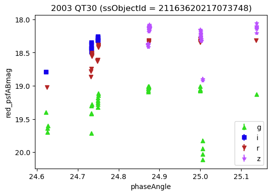

```python
x_plot = 'phaseAngle'
y_plot = 'red_{}'.format(mag_col)
yErr_plot = '{}Err'.format(mag_col)
filt_ref = 'r'

df_plot = df_obs[~any_flag_mask]

fig, ax = plt.subplots(figsize=(6, 4))

for i, filt in enumerate(np.unique(df_plot['band'])):
    _df_plot = df_plot[df_plot['band'] == filt]

    ax.errorbar(_df_plot[x_plot], _df_plot[y_plot], _df_plot[yErr_plot],
                c=filter_colors_white[filt],
                fmt=filter_symbols[filt],
                label=filt)

ax.legend()
ax.set_xlabel(x_plot)
ax.set_ylabel('{}'.format(y_plot))
ax.invert_yaxis()

plt.title(f"{mpcDes} (ssObjectId = {ssoid})")

plt.show()
```

> **Figure:** Scatter plot of the change in reduced magnitude as a function of phase angle, where observations in each filter are indicated. Normally the phase curve increases in brightness as phase angle decreases, but for this object the narrow phase angle coverage means that the probable rotational variation signal outweighs the expected phase curve trend (N.B. flagged outlying photometry has already been dropped). Analysis of the phase curve is reserved for when new observations extend the phase angle coverage.

## 4. Exercise for the learner

Repeat the lightcurve analysis with visit image magnitudes `scienceABmag` instead of difference image magnitudes `psfABmag`.